# MAB Rpath MSE test

Sarah Gaichas

June 18, 2026

## Introduction

The goal is to set up the Rpath MSE loop for the MAB Rpath model and integrate an MAFMC control rule. This starting point is based on code here https://github.com/thefaylab/cinar-mse-projects/tree/main/multispecies

## Load the balanced Mid Atlantic Rpath model

This model is the same used in S. Weisberg et al in press, comparing all three NEUS Rpaths.

This model has had discards removed for the paper above so I’m only using it for testing. We will want to add them back in for any real analysis.

```r
load(here::here("outputs/MAB_params_Rpath_no_disc.RData"))
load(here::here("outputs/MAB_Rpath_no_disc.RData"))

MAB <- Rpath::rpath(MAB.rpath.params) # gives same object as MAB.rpath loaded above
```

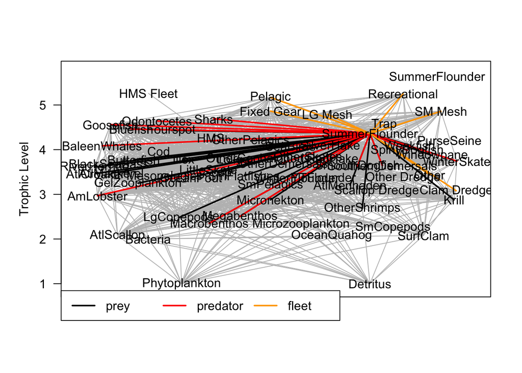

```r
#visualize a group
# the all-0 HMS Fleet breaks this plotting function
# add small HMS Fleet catch for HMS
hms_catch<-c(rep(0,14),0.003,rep(0,39),rep(NA,12))
MAB.rpath.params$model[,"HMS Fleet":=hms_catch]

MAB2 <- Rpath::rpath(MAB.rpath.params)

webplot(MAB2, labels=T, fleets=T, highlight = 'SummerFlounder') #fleets not working in MAB plot
```

These are simulated fishing scenarios to create contrast in biomass and catch.

```r
#Add variable fishing in a dynamic run
MAB.scene <- rsim.scenario(MAB, MAB.rpath.params, years = 1983:2022)

MAB.scene <- adjust.fishing(MAB.scene, parameter = 'ForcedEffort', group = 'LG Mesh',
                            sim.year = 1983:2017, value = c(rep(0, 15), rep(2.5, 5),
                                                            rep(5, 5), rep(10, 5),
                                                            rep(2.5, 5)))
MAB.scene <- adjust.fishing(MAB.scene, parameter = 'ForcedEffort', group = 'Fixed Gear',
                           sim.year = 1983:2017, value = c(rep(0, 15), rep(2.5, 5),
                                                           rep(5, 5), rep(10, 5),
                                                           rep(2.5, 5)))
MAB.scene <- adjust.fishing(MAB.scene, parameter = 'ForcedEffort', group = 'SM Mesh',
                            sim.year = 1983:2017, value = c(rep(0, 15), rep(1, 5),
                                                            rep(1.5, 5), rep(2, 5),
                                                            rep(0.5, 5)))
MAB.scene <- adjust.fishing(MAB.scene, parameter = 'ForcedEffort', group = 'Recreational',
                            sim.year = 1983:2017, value = c(rep(0, 15), rep(1, 5),
                                                            rep(1.5, 5), rep(2, 5),
                                                            rep(0.5, 5)))


MAB.run <- rsim.run(MAB.scene, years = 1983:2022)
```

This is the impact of the fishing scenarios we have implemented

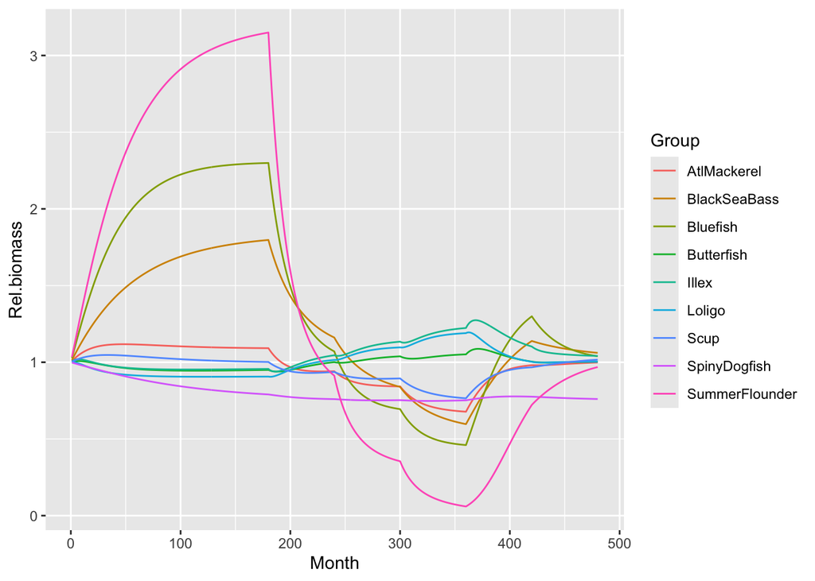

```r
#Plot results
MAB.bio <- as.data.table(MAB.run$out_Biomass)
MAB.bio[, Month := 1:nrow(MAB.bio)]
MAB.bio <- data.table::melt(MAB.bio, id.vars = 'Month', variable.name = 'Group',
                           value.name = 'Biomass')
start <- data.table::as.data.table(MAB.run$start_state$Biomass)
start[, Group := names(MAB.run$start_state$Biomass)]

MAB.bio <- merge(MAB.bio, start, by = 'Group')
MAB.bio[, Rel.biomass := Biomass / V1]

ggplot2::ggplot(MAB.bio[Group %in% c('SummerFlounder', 'Scup', 'Butterfish', 'SpinyDogfish',
                                     'BlackSeaBass', 'Bluefish', 'AtlMackerel', 'Loligo',
                                     'Illex')],
                ggplot2::aes(x = Month, y = Rel.biomass, col = Group)) +
  ggplot2::geom_line()
```

This function generates biomass and catch data from the system with both observation error and bias (if we want) No bias added here.

```r
#Need a function to pull observed data from the system:

GenData <- function(Rsim.output, group, sim.year, Sigma = 0.3, bias = 1, freq = 1){
  # This routine generates data (unbiased generally) for the biological groups
  #and returns the appropriate object

  node     <- extract.node(Rsim.output, group)
  TrueBio  <- node$AnnualBiomass[which(names(node$AnnualBiomass) == sim.year)]
  Observed <- c()
  for(Iyear in seq_along(sim.year)){
    if (Iyear %% freq == 0){
      Observed[Iyear] <- TrueBio[Iyear] * exp(rnorm(1, 0, Sigma) - Sigma^2/2)
    } else Observed[Iyear] <- -1
  }
  Catch <- as.numeric(node$AnnualTotalCatch[which(names(node$AnnualBiomass) == sim.year)])

  out <- list(ObsBio = Observed, TotCatch = Catch, Fmort = Catch / Observed)

  return(out)
}
```

These are the generated “datasets”

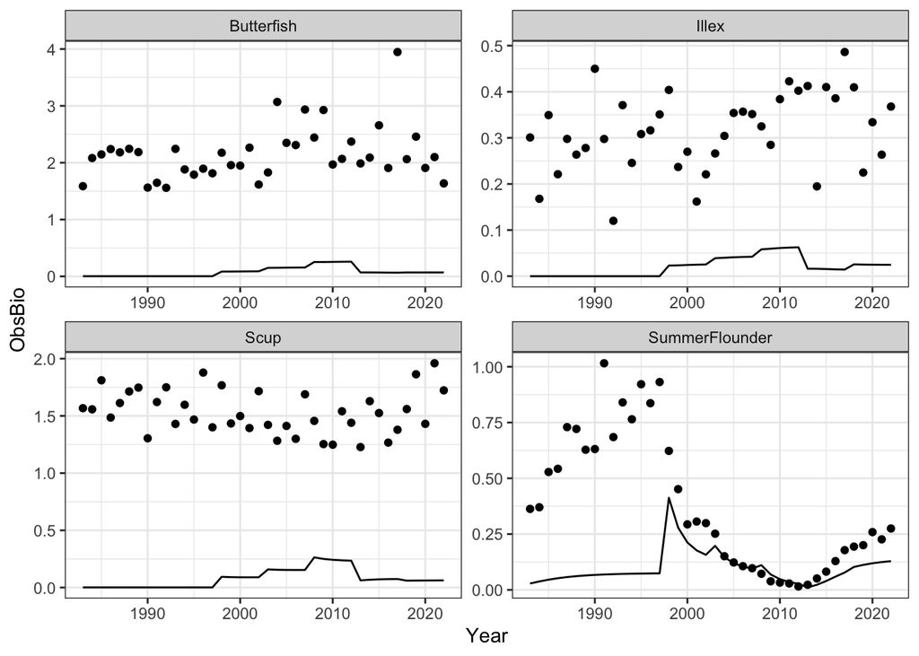

```r
#Now generate the initial data set and fit to a Schaefer production model

setkey(123)
sf <- GenData(MAB.run, 'SummerFlounder', 1983:2022, Sigma = 0.1)
scup <- GenData(MAB.run, 'Scup', 1983:2022, Sigma = 0.1)
butter <- GenData(MAB.run, 'Butterfish', 1983:2022, Sigma = 0.2)
illex <- GenData(MAB.run, 'Illex', 1983:2022, Sigma = 0.3)

#Merge into 1 file
MAB.data <- data.table(Year = 1983:2022,
                      Species = c(rep('SummerFlounder', 40), rep('Scup', 40),
                                  rep('Butterfish', 40), rep('Illex', 40)),
                      ObsBio = c(sf$ObsBio, scup$ObsBio, butter$ObsBio, illex$ObsBio),
                      TotCatch = c(sf$TotCatch, scup$TotCatch, butter$TotCatch, illex$TotCatch),
                      Fmort = c(sf$Fmort, scup$Fmort, butter$Fmort, illex$Fmort))

#plot
MAB.data |>
  ggplot2::ggplot()+
  ggplot2::geom_point(ggplot2::aes(x=Year, y=ObsBio)) +
  ggplot2::geom_line(ggplot2::aes(x=Year, y=TotCatch)) +
  ggplot2::theme_bw() +
  ggplot2::facet_wrap(~Species, scales = "free")
```